# Demo: Análise de tweets dos principais canais de Futebol do Brasil

## Nuvens de palavras (wordclouds)

Vamos contar a ocorrência de palavras para cada canal e depois montar uma nuvem de palavras de cada canal.

### GE Globo

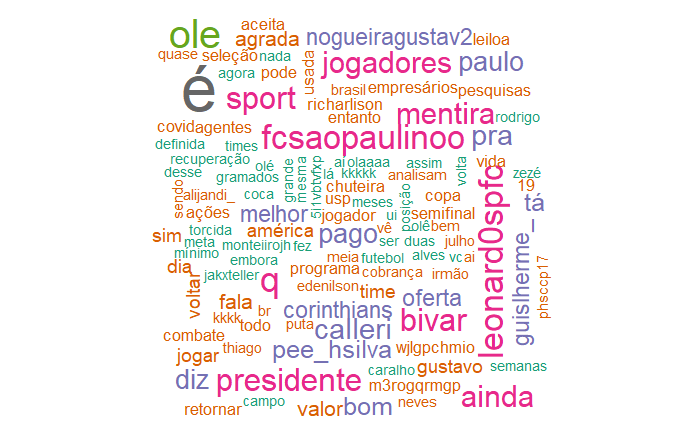

```r
top_GEGlobo <- top_clean_words %>%
  filter(canal == "GEGlobo")

wordcloud(top_GEGlobo$term, top_GEGlobo$n, colors = brewer.pal(8, "Dark2"))
```

### SL sportTV

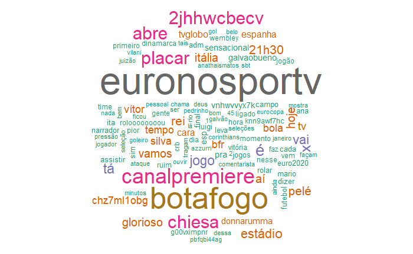

```r
top_sportTV <- top_clean_words %>%
  filter(canal == "sportTV")

wordcloud(top_sportTV$term, top_sportTV$n, colors = brewer.pal(8, "Dark2"))
```

### Fox Sports

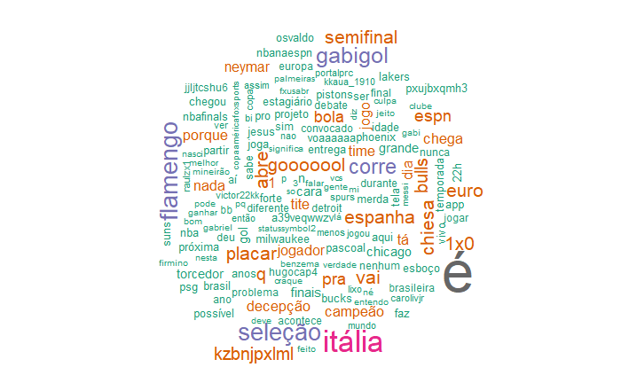

```r
top_FoxSports <- top_clean_words %>%
  filter(canal == "FoxSports")

wordcloud(top_FoxSports$term, top_FoxSports$n, colors = brewer.pal(8, "Dark2"))
```

### ESPN

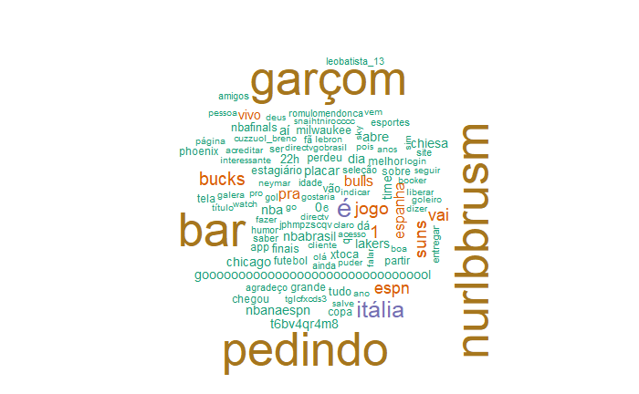

```r
top_ESPN <- top_clean_words %>%
  filter(canal == "ESPN")

wordcloud(top_ESPN$term, top_ESPN$n, colors = brewer.pal(8, "Dark2"))
```

## Análise de Sentimento

Em cada palavra carrega consigo um sentimento que pode ser bom (1), neutro (0) ou ruim (-1). Vou ver o sentimento transmitidos por algumas palavras.

```r
dicio <- oplexicon_v3.0 # Carrega dicionário de sentimentos

# Cinco palavras aleatórias
dicio[sample(1:nrow(dicio), 5) ,]
```

|  | term | type | polarity | polarity_revision |
| --- | --- | --- | --- | --- |
| 3604 | arguir | vb | -1 | A |
| 30842 | transverso | adj | -1 | A |
| 3244 | apele | adj | 0 | A |
| 20406 | jalofo | adj | -1 | A |
| 6910 | cimbrar | vb | 0 | A |

### GE Globo

```r
# Análise de sentimento dos tweets referentes ao GEGlobo
sentimento_GEGlobo <- tweets_canais_esportes %>%
  filter(canal == "GEGlobo") %>%  # Apenas tweets referentes ao GEGlobo
  unnest_tokens(term, text) %>%       # Quebra os tweets em palavras
  inner_join(dicio) %>%
  anti_join(stop_words, by = c("term" = "word")) %>%
  count(term, polarity, sort = TRUE) %>%
  ungroup()

sentimento_GEGlobo
```

| term | polarity | n |
| --- | --- | --- |
| cara | -1 | 15 |
| presidente | 0 | 13 |
| volante | 0 | 12 |
| ter | 0 | 11 |
| pago | 0 | 10 |
| bom | 1 | 9 |
| melhor | 1 | 8 |
| acontecer | 0 | 6 |
| jogar | 1 | 6 |
| voltar | -1 | 6 |

[output cut: 163 more lines]

### Sport TV

```r
# Análise de sentimento dos tweets referentes ao SportTV
sentimento_sportTV <- tweets_canais_esportes %>%
  filter(canal == "sportTV") %>%  # Apenas tweets referentes ao SportTV
  unnest_tokens(term, text) %>%     # Quebra os tweets em palavras
  inner_join(dicio) %>%
  anti_join(stop_words, by = c("term" = "word")) %>%
  count(term, polarity, sort = TRUE) %>%
  ungroup()

sentimento_sportTV
```

| term | polarity | n |
| --- | --- | --- |
| placar | 0 | 26 |
| glorioso | 1 | 13 |
| cara | -1 | 9 |
| sensacional | 1 | 7 |
| ana | -1 | 5 |
| assistir | 0 | 5 |
| dizer | 0 | 5 |
| final | 0 | 5 |
| rolar | 0 | 5 |
| ligado | -1 | 4 |

[output cut: 131 more lines]

### Fox Sports

```r
# Análise de sentimento dos tweets referentes ao Fox Sports
sentimento_FoxSports <- tweets_canais_esportes %>%
  filter(canal == "FoxSports") %>%  # Apenas tweets referentes ao Fox Sports
  unnest_tokens(term, text) %>%     # Quebra os tweets em palavras
  inner_join(dicio) %>%
  anti_join(stop_words, by = c("term" = "word")) %>%
  count(term, polarity, sort = TRUE) %>%
  ungroup()

sentimento_FoxSports
```

| term | polarity | n |
| --- | --- | --- |
| placar | 0 | 17 |
| nada | 0 | 11 |
| cara | -1 | 9 |
| finais | 0 | 9 |
| grande | 0 | 8 |
| torcedor | 0 | 8 |
| partir | -1 | 7 |
| vivo | 1 | 7 |
| forte | 1 | 6 |
| sabe | 1 | 6 |

[output cut: 146 more lines]

### ESPN

```r
# Análise de sentimento dos tweets referentes ao ESPN
sentimento_ESPN <- tweets_canais_esportes %>%
  filter(canal == "ESPN") %>%  # Apenas tweets referentes ao ESPN
  unnest_tokens(term, text) %>%     # Quebra os tweets em palavras
  inner_join(dicio) %>%
  anti_join(stop_words, by = c("term" = "word")) %>%
  count(term, polarity, sort = TRUE) %>%
  ungroup()

sentimento_ESPN
```

| term | polarity | n |
| --- | --- | --- |
| vivo | 1 | 9 |
| placar | 0 | 7 |
| finais | 0 | 6 |
| grande | 0 | 5 |
| melhor | 1 | 5 |
| partir | -1 | 5 |
| amigos | 1 | 4 |
| entregar | -1 | 4 |
| saber | 0 | 4 |
| ser | 1 | 4 |

[output cut: 76 more lines]

### Sentimento Geral

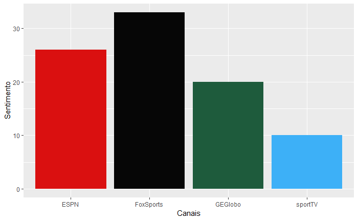

```r
tweets_canais_esportes %>%
  unnest_tokens(term, text) %>%
  anti_join(stop_words, by = c("term" = "word")) %>%
  inner_join(dicio) %>%
  group_by(canal) %>%
  summarise(sum(polarity)) %>%
  ggplot(aes(canal, `sum(polarity)`, fill = canal)) +
  geom_col(show.legend = FALSE) +
  scale_fill_manual(values = c("#da1010", "#060606", "#1e5b3c", "#3db0f7")) +
  labs(x = "Canais", y = "Sentimento")
```

## Calculando a Frequência das Palavras (TF)

Vamos calcular a frequência das palavras dentro dos Twitters dos canais:

```r
texto_canais <- tweets_canais_esportes %>%
  unnest_tokens(termo, text) %>%
  count(canal, termo, sort = TRUE) %>%
  ungroup()
total_texto_canais <- texto_canais %>%
  group_by(canal) %>%
  summarize(total = sum(n))
texto_canais <- left_join(texto_canais, total_texto_canais)
texto_canais
```

| canal | termo | n | total |
| --- | --- | --- | --- |
| GEGlobo | geglobo | 174 | 2995 |
| sportTV | sportv | 164 | 2609 |
| FoxSports | foxsportsbrasil | 150 | 3092 |
| FoxSports | o | 138 | 3092 |
| ESPN | espnbrasil | 124 | 2394 |
| ESPN | o | 104 | 2394 |
| sportTV | o | 97 | 2609 |
| GEGlobo | o | 89 | 2995 |
| ESPN | https | 85 | 2394 |
| ESPN | t.co | 85 | 2394 |

[output cut: 990 more lines]

Agora, realizarmos o calculo da Frequencia dos Termos (TF) por canal:

```r
tf_texto_canais_by_rank <- texto_canais %>%
  group_by(canal) %>%
  mutate(rank = row_number(),
         `TF` = n/total)
tf_texto_canais_by_rank
```

| canal | termo | n | total | rank | TF |
| --- | --- | --- | --- | --- | --- |
| GEGlobo | geglobo | 174 | 2995 | 1 | 0.0580968280 |
| sportTV | sportv | 164 | 2609 | 1 | 0.0628593331 |
| FoxSports | foxsportsbrasil | 150 | 3092 | 1 | 0.0485122898 |
| FoxSports | o | 138 | 3092 | 2 | 0.0446313066 |
| ESPN | espnbrasil | 124 | 2394 | 1 | 0.0517961571 |
| ESPN | o | 104 | 2394 | 2 | 0.0434419382 |
| sportTV | o | 97 | 2609 | 2 | 0.0371789958 |
| GEGlobo | o | 89 | 2995 | 2 | 0.0297161937 |
| ESPN | https | 85 | 2394 | 3 | 0.0355054302 |
| ESPN | t.co | 85 | 2394 | 4 | 0.0355054302 |

[output cut: 990 more lines]

E por fim, um plot com os termos:

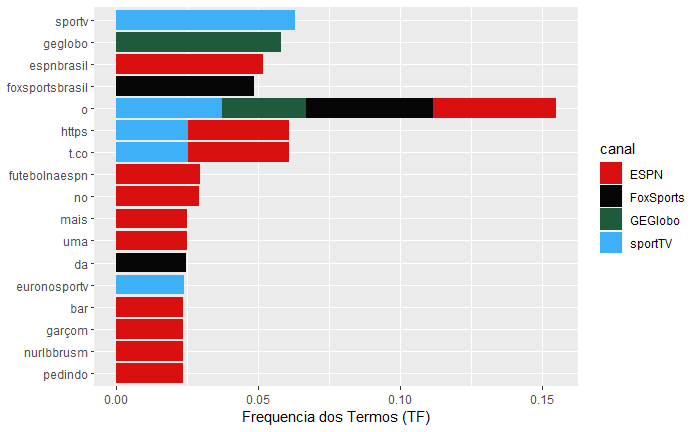

```r
plot_canais_tf <- tf_texto_canais_by_rank %>%
  ungroup(tf_texto_canais_by_rank) %>%
  arrange(desc(TF)) %>%
  mutate(termo = factor(termo, levels = rev(unique(termo))))
plot_canais_tf %>%
  top_n(20) %>%
  ggplot(aes(termo, TF, fill = canal)) +
  scale_fill_manual(values=c("#da1010", "#060606", "#1e5b3c", "#3db0f7")) +
  geom_col() +
  labs(x = NULL, y = "Frequencia dos Termos (TF)") +
  coord_flip()
```

## Calculando a Freqüência Inversa no Documento (IDF)

Sparck Jones desenvolveu uma interpretação estatística da especificidade dos termos (1972), chamada de IDF.

```r
texto_canais_tf_idf <- texto_canais %>%
  bind_tf_idf(termo, canal, n)

texto_canais_tf_idf
```

| canal | termo | n | total | tf | idf | tf_idf |
| --- | --- | --- | --- | --- | --- | --- |
| GEGlobo | geglobo | 174 | 2995 | 0.0580968280 | 0.6931472 | 0.0402696526 |
| sportTV | sportv | 164 | 2609 | 0.0628593331 | 0.6931472 | 0.0435707695 |
| FoxSports | foxsportsbrasil | 150 | 3092 | 0.0485122898 | 1.3862944 | 0.0672523138 |
| FoxSports | o | 138 | 3092 | 0.0446313066 | 0.0000000 | 0.0000000000 |
| ESPN | espnbrasil | 124 | 2394 | 0.0517961571 | 1.3862944 | 0.0718047205 |
| ESPN | o | 104 | 2394 | 0.0434419382 | 0.0000000 | 0.0000000000 |
| sportTV | o | 97 | 2609 | 0.0371789958 | 0.0000000 | 0.0000000000 |
| GEGlobo | o | 89 | 2995 | 0.0297161937 | 0.0000000 | 0.0000000000 |
| ESPN | https | 85 | 2394 | 0.0355054302 | 0.0000000 | 0.0000000000 |
| ESPN | t.co | 85 | 2394 | 0.0355054302 | 0.0000000 | 0.0000000000 |

[output cut: 990 more lines]

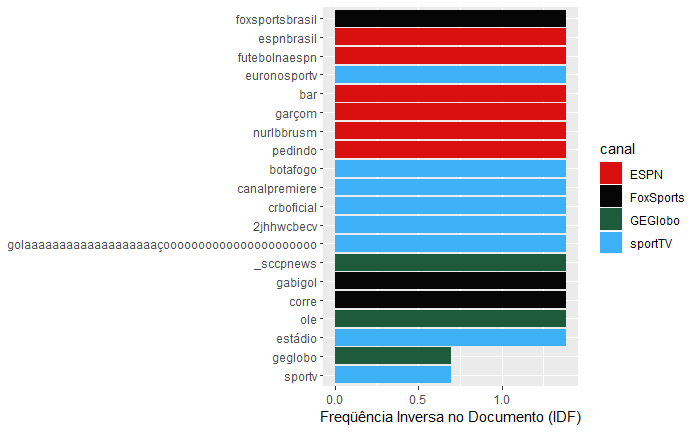

```r
plot_canais_idf <- texto_canais_tf_idf %>%
  ungroup(texto_canais_tf_idf) %>%
  arrange(desc(idf)) %>%
  mutate(termo = factor(termo, levels = rev(unique(termo))))

plot_canais_idf %>%
  top_n(20) %>%
  ggplot(aes(termo, idf, fill = canal)) +
  scale_fill_manual(values=c("#da1010", "#060606", "#1e5b3c", "#3db0f7")) +
  geom_col() +
  labs(x = NULL, y = "Freqüência Inversa no Documento (IDF)") +
  coord_flip()
```

## Calculando a ponderação TF-IDF

```r
texto_canais_tf_idf %>%
  select(-total) %>%
  arrange(desc(tf_idf))
```

| canal | termo | n | tf | idf | tf_idf |
| --- | --- | --- | --- | --- | --- |
| ESPN | espnbrasil | 124 | 0.0517961571 | 1.3862944 | 0.0718047205 |
| FoxSports | foxsportsbrasil | 150 | 0.0485122898 | 1.3862944 | 0.0672523138 |
| sportTV | sportv | 164 | 0.0628593331 | 0.6931472 | 0.0435707695 |
| ESPN | futebolnaespn | 71 | 0.0296574770 | 1.3862944 | 0.0411139932 |
| GEGlobo | geglobo | 174 | 0.0580968280 | 0.6931472 | 0.0402696526 |
| sportTV | euronosportv | 62 | 0.0237638942 | 1.3862944 | 0.0329437525 |
| ESPN | bar | 56 | 0.0233918129 | 1.3862944 | 0.0324279383 |
| ESPN | garçom | 56 | 0.0233918129 | 1.3862944 | 0.0324279383 |
| ESPN | nurlbbrusm | 56 | 0.0233918129 | 1.3862944 | 0.0324279383 |
| ESPN | pedindo | 56 | 0.0233918129 | 1.3862944 | 0.0324279383 |

[output cut: 990 more lines]

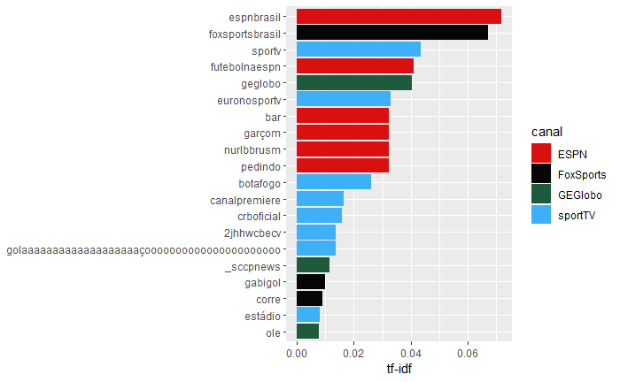

```r
plot_canais_tf_idf <- texto_canais_tf_idf %>%
  arrange(desc(tf_idf)) %>%
  mutate(termo = factor(termo, levels = rev(unique(termo))))
plot_canais_tf_idf %>%
  top_n(20) %>%
  ggplot(aes(termo, tf_idf, fill = canal)) +
  scale_fill_manual(values=c("#da1010", "#060606", "#1e5b3c", "#3db0f7")) +
  geom_col() +
  labs(x = NULL, y = "tf-idf") +
  coord_flip()
```

Agora, para cada canal:

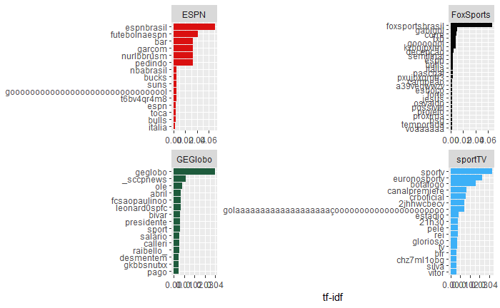

```r
plot_canais_tf_idf %>%
  group_by(canal) %>%
  top_n(15) %>%
  ungroup %>%
  ggplot(aes(termo, tf_idf, fill = canal)) +
  scale_fill_manual(values=c("#da1010", "#060606", "#1e5b3c", "#3db0f7")) +
  geom_col(show.legend = FALSE) +
  labs(x = NULL, y = "tf-idf") +
  facet_wrap(~canal, ncol = 2, scales = "free") +
  coord_flip()
```

## Bigrama

Abaixo, vamos obter os Bigramas dos tweets:

```r
bigramas_tweets_canais_esportes <- tweets_canais_esportes %>%
  unnest_tokens(bigrama, text, token = "ngrams", n = 2)

bigramas_tweets_canais_esportes
```

| canal | created_at | bigrama |
| --- | --- | --- |
| ESPN | 2021-07-06 19:28:32 | espnbrasil me |
| ESPN | 2021-07-06 19:28:32 | me ajudem |
| ESPN | 2021-07-06 19:28:32 | ajudem a |
| ESPN | 2021-07-06 19:28:32 | a comprar |
| ESPN | 2021-07-06 19:28:32 | comprar alimento |
| ESPN | 2021-07-06 19:28:32 | alimento se |
| ESPN | 2021-07-06 19:28:32 | se vocês |
| ESPN | 2021-07-06 19:28:32 | vocês poderem |
| ESPN | 2021-07-06 19:28:32 | poderem ajudar |
| ESPN | 2021-07-06 19:28:32 | ajudar com |

[output cut: 990 more lines]

Recalculando o TF-IDF com o Bigrama:

```r
bigramas_tweets_texto_canais <- bigramas_tweets_canais_esportes %>%
  count(canal, bigrama, sort = TRUE) %>%
  ungroup()
total_bigramas_tweets_texto_canais <- bigramas_tweets_texto_canais %>%
  group_by(canal) %>%
  summarize(total = sum(n))
bigramas_tweets_texto_canais <- left_join(bigramas_tweets_texto_canais, total_bigramas_tweets_texto_canais)
bigramas_tweets_texto_canais_tf_idf <- bigramas_tweets_texto_canais %>%
  bind_tf_idf(bigrama, canal, n)
bigramas_tweets_texto_canais_tf_idf %>%
  select(-total) %>%
  arrange(desc(tf_idf))
```

| canal | bigrama | n | tf | idf | tf_idf |
| --- | --- | --- | --- | --- | --- |
| ESPN | futebolnaespn https | 68 | 0.0308110557 | 1.3862944 | 0.0427131928 |
| ESPN | bar o | 56 | 0.0253738106 | 1.3862944 | 0.0351755706 |
| ESPN | garçom futebolnaespn | 56 | 0.0253738106 | 1.3862944 | 0.0351755706 |
| ESPN | mais uma | 56 | 0.0253738106 | 1.3862944 | 0.0351755706 |
| ESPN | no bar | 56 | 0.0253738106 | 1.3862944 | 0.0351755706 |
| ESPN | o garçom | 56 | 0.0253738106 | 1.3862944 | 0.0351755706 |
| ESPN | pedindo mais | 56 | 0.0253738106 | 1.3862944 | 0.0351755706 |
| ESPN | t.co nurlbbrusm | 56 | 0.0253738106 | 1.3862944 | 0.0351755706 |
| ESPN | uma no | 56 | 0.0253738106 | 1.3862944 | 0.0351755706 |
| sportTV | euronosportv https | 45 | 0.0185873606 | 1.3862944 | 0.0257675532 |

[output cut: 990 more lines]

Vamos fazer um plot para cada canal:

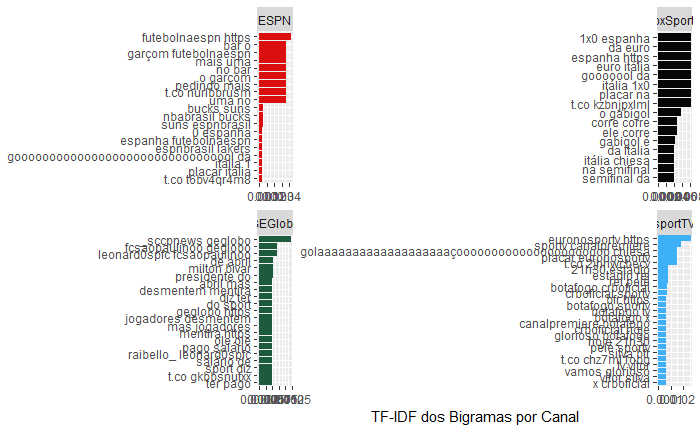

```r
plot_canais_tf_idf_bigrama <- bigramas_tweets_texto_canais_tf_idf %>%
  arrange(desc(tf_idf)) %>%
  mutate(bigrama = factor(bigrama, levels = rev(unique(bigrama))))
plot_canais_tf_idf_bigrama %>%
  group_by(canal) %>%
  top_n(15) %>%
  ungroup %>%
  ggplot(aes(bigrama, tf_idf, fill = canal)) +
  geom_col(show.legend = FALSE) +
  labs(x = NULL, y = "TF-IDF dos Bigramas por Canal") +
  scale_fill_manual(values=c("#da1010", "#060606", "#1e5b3c", "#3db0f7")) +
  facet_wrap(~canal, ncol = 2, scales = "free") +
  coord_flip()
```

Visualização com nuvem de palavras das 100 bigramas com maior tf-idf de cada canal:

### GE Globo

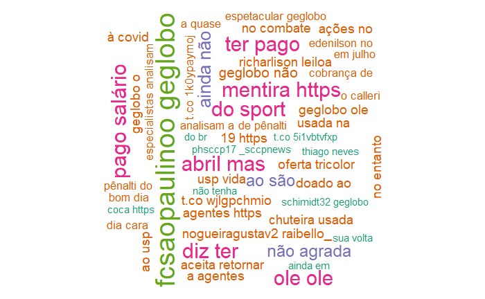

```r
top_GEGlobo_bigramas_tf_idf <- bigramas_tweets_texto_canais_tf_idf %>%
  filter(canal == "GEGlobo")

wordcloud(top_GEGlobo_bigramas_tf_idf$bigrama[!is.na(top_GEGlobo_bigramas_tf_idf$tf_idf)], top_GEGlobo_bigramas_tf_idf$tf_idf[!is.na(top_GEGlobo_bigramas_tf_idf$tf_idf)], colors = brewer.pal(8, "Dark2"), max.words= 100)
```

### SportTV

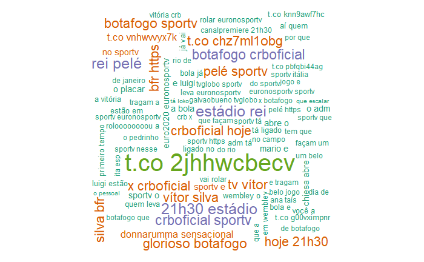

```r
top_sportTV_bigramas_tf_idf <- bigramas_tweets_texto_canais_tf_idf %>%
  filter(canal == "sportTV")

wordcloud(top_sportTV_bigramas_tf_idf$bigrama[!is.na(top_sportTV_bigramas_tf_idf$tf_idf)], top_sportTV_bigramas_tf_idf$tf_idf[!is.na(top_sportTV_bigramas_tf_idf$tf_idf)], colors = brewer.pal(8, "Dark2"), max.words= 100)
```

### Fox Sports

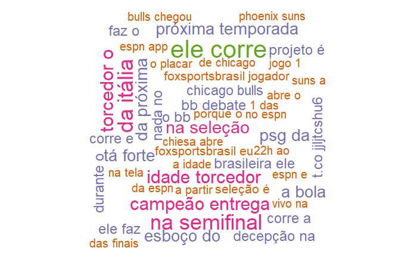

```r
top_FoxSports_bigramas_tf_idf <- bigramas_tweets_texto_canais_tf_idf %>%
  filter(canal == "FoxSports")

wordcloud(top_FoxSports_bigramas_tf_idf$bigrama[!is.na(top_FoxSports_bigramas_tf_idf$tf_idf)], top_FoxSports_bigramas_tf_idf$tf_idf[!is.na(top_FoxSports_bigramas_tf_idf$tf_idf)], colors = brewer.pal(8, "Dark2"), max.words= 100)
```

### ESPN

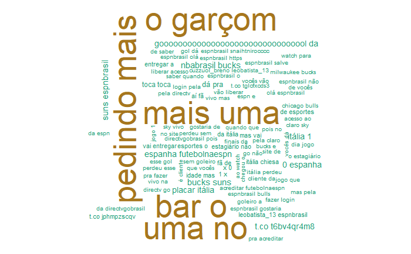

```r
top_ESPN_bigramas_tf_idf <- bigramas_tweets_texto_canais_tf_idf %>%
  filter(canal == "ESPN" & !is.na(bigrama))

wordcloud(top_ESPN_bigramas_tf_idf$bigrama[!is.na(top_ESPN_bigramas_tf_idf$tf_idf)], top_ESPN_bigramas_tf_idf$tf_idf[!is.na(top_ESPN_bigramas_tf_idf$tf_idf)], colors = brewer.pal(8, "Dark2"), max.words= 100)
```

## Referências

- [Cliente R para API do Twitter](https://github.com/mkearney/rtweet)
- [Text Mining With R](http://tidytextmining.com/)
- [Introdução à Mineração de Textos - By Andrei Martins e Charles Mendes](https://github.com/MackMendes/MineracaoTexto-Nerdzao)